# Bullet Graph

Marco Torchiano

2015-01-05

This documents reproduces the original [Bullet Graph Design Specification](http://www.perceptualedge.com/articles/misc/Bullet_Graph_Design_Spec.pdf) by Stephen Few (pending permission).

In addition it shows the `R` code that is used to generate the graphs (omitting a few embellishments and decorations)

## Overview

The bullet graph was developed to replace the meters and gauges that are often used on dashboards. Its linear and no-frills design provides a rich display of data in a small space, which is essential on a dashboard. Like most meters and gauges, bullet graphs feature a single quantitative measure (for example, year-to-date revenue) along with complementary measures to enrich the meaning of the featured measure. Specifically, bullet graphs support the comparison of the featured measure to one or more related measures (for example, a target or the same measure at some point in the past, such as a year ago) and relate the featured measure to defined quantitative ranges that declare its qualitative state (for example, good, satisfactory, and poor). Its linear design not only gives it a small footprint, but also supports more efficient reading than radial meters.

The bullet graph consists of five primary components:

- Text label
- A quantitative scale along a single linear axis
- The featured measure
- One or two comparative measures (optional)
- From two to five ranges along the quantitative scale to declare the featured measure’s qualitative state (optional)

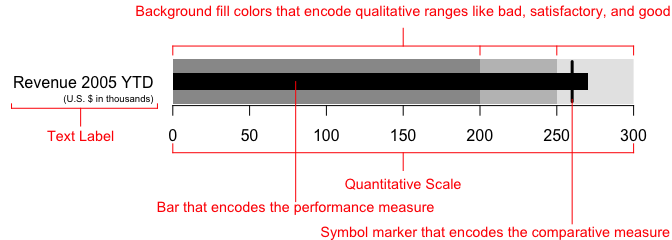

```r
bulletgraph(x=270,ref=260,limits=c(0,200,250,300),
            name= "Revenue 2005 YTD",
            subname="(U.S. $ in thousands)")
```

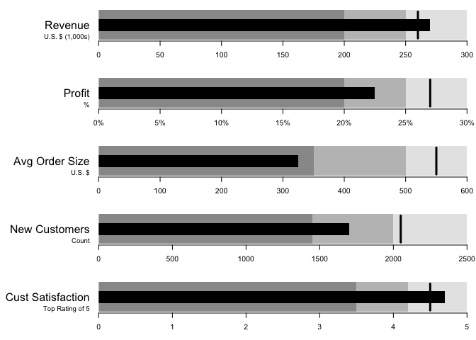

```r
par(mfrow=c(5,1))
par(mar=c(3,11,1,1))
bulletgraph(x=270,ref=260,limits=c(0,200,250,300),
            name= "Revenue",subname="U.S. $ (1,000s)",cex.names=1.5)
bulletgraph(x=.225,ref=.27,limits=c(0,.2,.25,.3),
            name= "Profit",subname="%",cex.names=1.5)
bulletgraph(x=325,ref=550,limits=c(0,350,500,600),
            name= "Avg Order Size",subname="U.S. $",cex.names=1.5)
bulletgraph(x=1700,ref=2050,limits=c(0,1450,2000,2500),
            name= "New Customers",subname="Count",cex.names=1.5)
bulletgraph(x=4.7,ref=4.5,limits=c(0,3.5,4.2,5),
            name= "Cust Satisfaction",subname="Top Rating of 5",cex.names=1.5)
```

## The Text Label

This portion of the bullet graph identifies the measure.

#### Formatting Defaults:

- *Position*. To the left of horizontally-oriented graphs and above vertically-oriented graphs
- *Color, orientation, and size*. 100% black, horizontally oriented, and large enough to be easily read

## The Quantitative Scale

This portion of the bullet graph looks and functions just like the quantitative scale on a two-dimensional XY graph. It consists of tick marks and text labels that identify equal intervals of measure along the bottom or top of the graph when oriented horizontally or along the left or right of the graph when oriented vertically. The tick marks may be positioned along either the inside or outside edge of the plot area. The quantitative range usually begins at zero, but may begin with a negative number if appropriate, and may also begin at a value greater than zero if it is useful to narrow the range of the scale to support a finer focus on the details.

## The Featured Measure

This portion of the bullet graph displays the primary data and should therefore be visually prominent. Usually, it should be encoded as a bar, like the bar on a bar graph. The one exception is when the quantitative scale begins at a value greater than zero; in such a case, the featured measure should be encoded as a symbol such as a dot or X.

#### Formatting Defaults:

- *Position*. Centered in the plot area with the endpoint aligned with its value along the quantitative scale
- *Color and stroke*. 100% black with a heavy stroke weight
- *Thickness*. Approximately 1/3rd the thickness of its container.
- *Border*. None

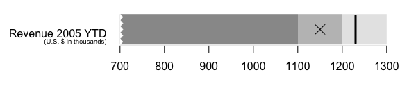

```r
par(mar=c(3,9,1,1))
bulletgraph(x=1150,ref=1230,limits=c(700,1100,1200,1300),
            name= "Revenue 2005 YTD",
            subname="(U.S. $ in thousands)")
```

## The Comparative Measure(s)

#### Formatting Defaults:

- *Position*. Centered in the plot area and aligned with its value along the quantitative scale
- *Color and Stroke*. 100% black with a stroke that is clearly visible but less dominant than the featured measure. When a second comparative measure is included, it should be 75% black.

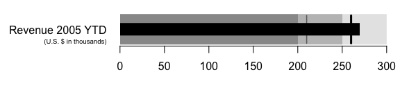

```r
par(mar=c(3,9,1,1))
bulletgraph(x=270,ref=c(260,210),limits=c(0,200,250,300),
            name= "Revenue 2005 YTD",subname="(U.S. $ in thousands)")
```

## The Qualitative Ranges

These ranges not only communicate the qualitative state of the featured measure but also the degree to which it resides within that state. For instance, if the measure extends into a range that represents “good”, the distance that it travels into this range indicates how good it is. The number of qualitative ranges should be limited to a maximum of five and ideally to three. More than five qualitative states would require a level of perceptual reasoning that is not efficient enough for a dashboard. The range should be encoded as rectangles of fill color behind the measures laid out end-to-end, which combine to define the entire plot area of the graph.

#### Formatting Defaults:

- *Color*. Rather than using distinct hues, which might not be distinguishable by those who are colorblind, encode these ranges as distinct intensities from dark to light of a single hue. Use the darker color intensities for the poor states and the lighter color intensities for the favorable states. Use these intensities for the following numbers of ranges:
  - Two: 35% and 10% black
  - Three: 40%, 25%, and 10% black
  - Four: 50%, 35%, 20%, and 10% black
  - Five: 50%, 35%, 20%, 10%, and 3% black
- *Border*. None

## Alternative Designs

There are occasions when alternatives to the standard design of bullet graphs work more effectively. Two situations are common:

1. Both positive and negative values might need to be displayed in the bullet graph
2. When a series of related bullet graphs includes some values that are considered good when they are high and some that are considered good when they are low, this distinction should be apparent

When a bullet graph needs to express both positive and negative values, such as one that is used to display profits that could go negative, in the case of losses, the following design can handle this quite well:

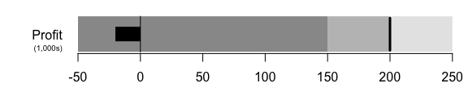

```r
par(mar=c(3,5,1,1))
bulletgraph(x=-20,ref=200,limits=c(-50,150,200,250),
            name= "Profit",subname="(1,000s)")
```

When a bullet graph is being used to display a value that should be interpreted differently than others that are shown, such as expenses, which are best when low rather than high, this difference can be represented in both of the following ways.

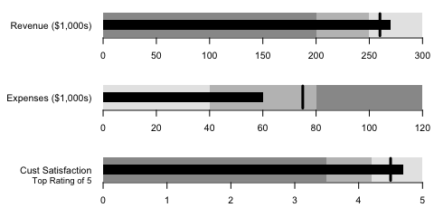

```r
par(mfrow=c(3,1))
par(mar=c(3,9,1,1))
bulletgraph(x=270,ref=260,limits=c(0,200,250,300),
            name= "Revenue ($1,000s)")
bulletgraph(x=60,ref=75,limits=c(0,40,80,120),
            name= "Expenses ($1,000s)",
            reverse=T)
bulletgraph(x=4.7,ref=4.5,limits=c(0,3.5,4.2,5),
            name= "Cust Satisfaction",subname="Top Rating of 5")
```

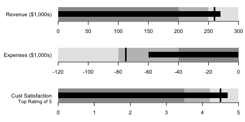

```r
par(mfrow=c(3,1))
par(mar=c(3,9,1,1))
bulletgraph(x=270,ref=260,limits=c(0,200,250,300),
            name= "Revenue ($1,000s)")
bulletgraph(x=-60,ref=-75,limits=-c(0,40,80,120),
            name= "Expenses ($1,000s)",
            reverse=T)
bulletgraph(x=4.7,ref=4.5,limits=c(0,3.5,4.2,5),
            name= "Cust Satisfaction",subname="Top Rating of 5")
```

Besides expenses, another example of this is the display of defects in a manufacturing process, which we want to remain below some defined threshold.

## Optional Features

Whenever you compare a current measure to a future target (for example, revenue as of January 15 compared to a Quarter 1 target), you can easily see how far you are from the target, but it’s not always so easy to tell if you are on track to meet or surpass that future target, which could still be weeks or even months away. This is true whether you are using a bullet graph or any other graphical means to display this information. This shortcoming in the usefulness of the comparison can be ameliorated by adding a projection of where you’ll be at the end of the period of time that is relevant to the target. This provides a rich display that tells you not only how far along you are on the path to the future target, but also how well you’re doing today in relation to that target.

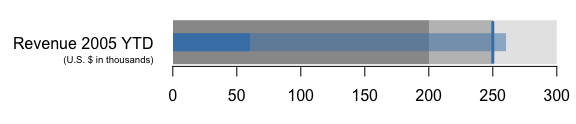

```r
par(mar=c(3,9,1,1))
bulletgraph(x=60,ref=c(250),limits=c(0,200,250,300),
            projection=260,
            col="steelblue",
            name= "Revenue 2005 YTD",subname="(U.S. $ in thousands)")
```